# 03 — ARIMA & Prophet Validation

This notebook models the **daily return dynamics** of the **IBEX 35 (Spain)** and **S&P 500 (US)** indices using two complementary forecasting frameworks:  
an **ARIMA** model and a **Prophet** approach.

The goal is to evaluate short-term predictability in financial returns, compare their statistical validity, and establish a base for later volatility modeling (EGARCH).

### Objectives

- Identify and validate autoregressive patterns in the return series.
- Estimate ARIMA and Prophet models for both indices.
- Evaluate model residuals through statistical tests.
- Compare forecast accuracy using MAE, RMSE, and Diebold–Mariano tests.

| File | Description |
| --- | --- |
| `/data/features/returns.csv` | Daily log-returns of IBEX 35 and S&P 500. |

### Outputs

| File | Description |
| --- | --- |
| `/figures/arima_acf_pacf_ibex.png` | ACF/PACF diagnostics for IBEX returns. |
| `/figures/arima_forecast_ibex.png` | ARIMA 1-day and 5-day forecasts for IBEX. |
| `/figures/prophet_forecast_spx.png` | Prophet 1-day and 5-day forecasts for S&P 500. |
| `/data/models/arima_prophet_metrics.csv` | Forecast metrics (MAE, RMSE, DM-test). |

### Tests to be Performed

[output not shown]

### Notebook Structure

1. **Data Loading & Setup** import return series and verify properties.
2. **ARIMA Modeling** identify, estimate, and validate ARIMA models.
3. **Prophet Modeling** estimate Prophet forecasts for both indices.
4. **Model Comparison** evaluate performance metrics and statistical tests.
5. **Analytical Insights** interpret forecasting implications and transition to volatility modeling.
6. **Power BI Export Summary** generate a dataset (arima_prophet_metrics.csv)

## 1. Data Loading & Setup

We begin by importing the daily log-return series stored in `/data/features/returns.csv` using the modular `load_returns_data()` function from `src/data_utils.py`.

```python
# PATH CONFIGURATION
import sys
from pathlib import Path

ROOT = Path.cwd().parent
if str(ROOT) not in sys.path:
    sys.path.append(str(ROOT))

# IMPORTS
from src import data_utils

# To load data
returns = data_utils.load_returns_data()
returns.head()
```

| Date | IBEX_ret | SPX_ret |
| --- | --- | --- |
| 2000-01-04 | -0.035364 | -0.039099 |
| 2000-01-05 | -0.031131 | 0.001920 |
| 2000-01-07 | 0.021790 | 0.027685 |
| 2000-01-10 | 0.006366 | 0.011128 |
| 2000-01-11 | -0.014505 | -0.013149 |

### Context plot visualisation

Before model estimation, it’s useful to recall the behaviour of daily returns analysed in the EDA stage.  
The figure below, generated in `/notebooks/02_EDA.ipynb`, shows the log-return trajectories of IBEX 35 and S&P 500, confirming volatility clustering and short-term mean reversion.

[figure not shown]

## 2. ARIMA Modeling

To model short-term dependencies in financial returns, we use an **ARIMA(p,d,q)** specification.

$$ \phi(L)\,(1 - L)^d\, y_t = \theta(L)\,\varepsilon_t $$

This formulation allows ARIMA to capture short-memory patterns in returns, making it a natural benchmark for forecasting the IBEX 35 and S&P 500 under a parsimonious and statistically grounded framework.

This section focuses on fitting ARIMA models to the daily returns of the IBEX 35 and S&P 500 indices.  
We identify the optimal model orders (p, d, q) using information criteria, estimate the parameters, validate residuals with diagnostic tests, and generate short-term forecasts (1-day and 5-day).

```python
from src import data_utils

# Load daily return data
returns = data_utils.load_returns_data()

print("Data loaded successfully:")
print(returns.head(), "\n")
print(f"Columns: {list(returns.columns)}")
```

```
Data loaded successfully:
            IBEX_ret   SPX_ret
Date
2000-01-04 -0.035364 -0.039099
2000-01-05 -0.031131  0.001920
2000-01-07  0.021790  0.027685
2000-01-10  0.006366  0.011128
2000-01-11 -0.014505 -0.013149

Columns: ['IBEX_ret', 'SPX_ret']
```

```python
# GLOBAL SETUP — Load Clean Return Data
import sys
from pathlib import Path

# Define ROOT to the project root
ROOT = Path.cwd().parent
if str(ROOT) not in sys.path:
    sys.path.append(str(ROOT))

# Import the project package
from src import data_utils

# Load daily return data
returns = data_utils.load_returns_data()

print("Data loaded successfully:")
print(returns.head(), "\n")
print(f"Columns: {list(returns.columns)}")
```

```
Data loaded successfully:
            IBEX_ret   SPX_ret
Date
2000-01-04 -0.035364 -0.039099
2000-01-05 -0.031131  0.001920
2000-01-07  0.021790  0.027685
2000-01-10  0.006366  0.011128
2000-01-11 -0.014505 -0.013149

Columns: ['IBEX_ret', 'SPX_ret']
```

```
Figures will be saved in: /home/apalo/projects/ibex-sp500-forecasting/figures/03.ARIMA
Models will be saved in: /home/apalo/projects/ibex-sp500-forecasting/data/models

Step 1 — ACF and PACF diagnostics
```

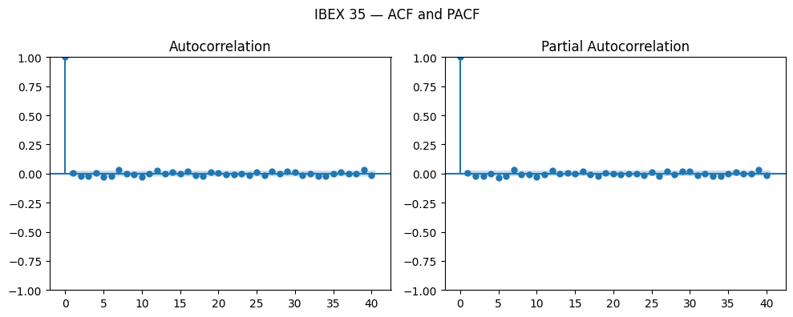

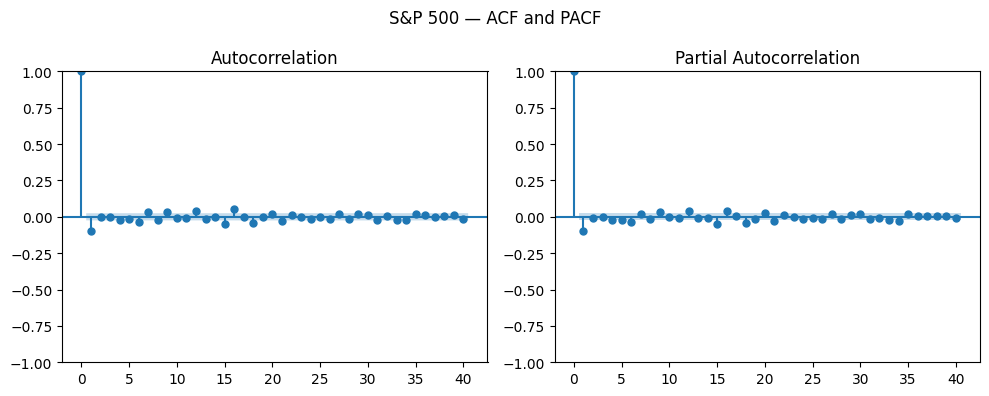

```
Step 2 — Estimating optimal ARIMA models (AIC criterion)

IBEX 35: Best ARIMA order (0, 0, 0) with AIC=-36372.74
S&P 500: Best ARIMA order (0, 0, 1) with AIC=-38315.32
IBEX 35 ARIMA summary
```

|  | 0 | 1 | 2 | 3 | 4 | 5 | 6 |
| --- | --- | --- | --- | --- | --- | --- | --- |
| 0 |  | coef | std err | z | P>\|z\| | [0.025 | 0.975] |
| 1 | const | 4.866e-05 | 0.000 | 0.272 | 0.785 | -0.000 | 0.000 |
| 2 | sigma2 | 0.0002 | 1.61e-06 | 125.987 | 0.000 | 0.000 | 0.000 |

```
 S&P 500 ARIMA summary
```

|  | 0 | 1 | 2 | 3 | 4 | 5 | 6 |
| --- | --- | --- | --- | --- | --- | --- | --- |
| 0 |  | coef | std err | z | P>\|z\| | [0.025 | 0.975] |
| 1 | const | 0.0002 | 0.000 | 1.608 | 0.108 | -5.03e-05 | 0.001 |
| 2 | ma.L1 | -0.1019 | 0.006 | -15.699 | 0.000 | -0.115 | -0.089 |
| 3 | sigma2 | 0.0001 | 1.12e-06 | 133.875 | 0.000 | 0.000 | 0.000 |

```
Step 3 — Residual diagnostics
Residual diagnostics saved → /home/apalo/projects/ibex-sp500-forecasting/data/models/arima_residual_tests.csv
```

|  | Model | LjungBox_p | JarqueBera_p |
| --- | --- | --- | --- |
| 0 | IBEX 35 | NaN | NaN |
| 0 | S&P 500 | NaN | NaN |

```
Step 4 — Forecasts

Forecast results:
```

|  | Horizon | Forecast | Model |
| --- | --- | --- | --- |
| 0 | 1 | 0.000049 | IBEX 35 |
| 1 | 5 | 0.000049 | IBEX 35 |

|  | Horizon | Forecast | Model |
| --- | --- | --- | --- |
| 0 | 1 | 0.000745 | S&P 500 |
| 1 | 5 | 0.000230 | S&P 500 |

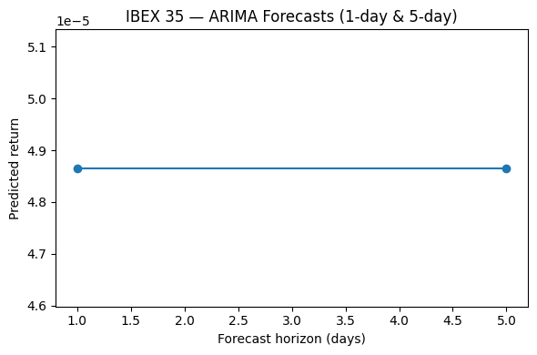

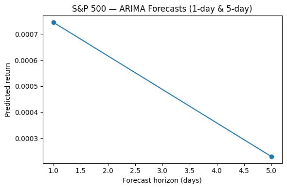

```
✓ ARIMA modeling complete — results and figures displayed.
```

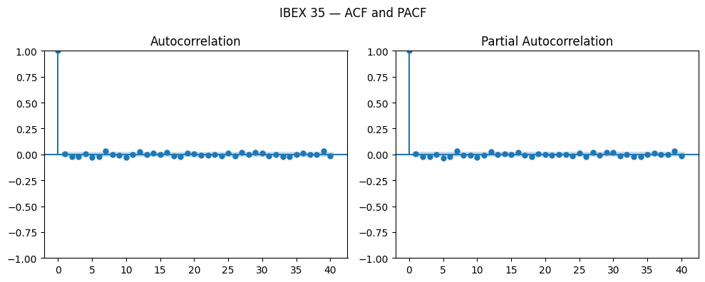

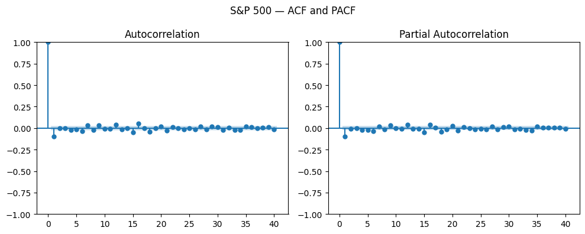

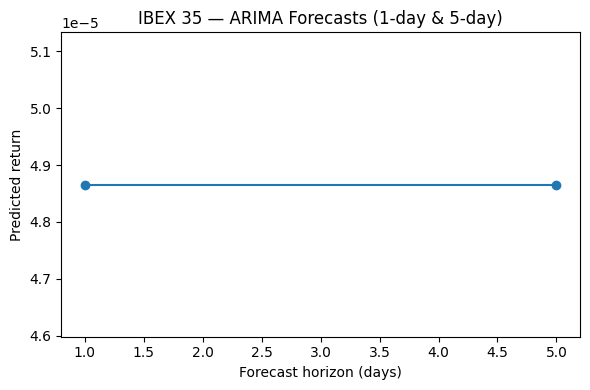

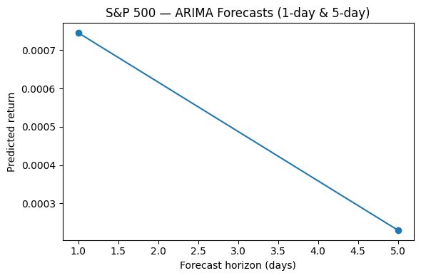

```python
# 2. ARIMA MODELING

# Imports
import warnings
from pathlib import Path
import pandas as pd
import matplotlib.pyplot as plt
from IPython.display import display

# Project modules
from src.models import estimate_arima, forecast_arima, validate_residuals
from src.visualization import plot_acf_pacf, plot_forecast

# Enable inline graphics for Jupyter
%matplotlib inline

# Setup directories and suppress warnings

# Define folders
FIG_DIR = ROOT / "figures" / "03.ARIMA"
MODEL_DIR = ROOT / "data" / "models"
FIG_DIR.mkdir(parents=True, exist_ok=True)
MODEL_DIR.mkdir(parents=True, exist_ok=True)

# Enforce business-day frequency to avoid warnings
returns = returns.asfreq("B")

# Suppress all frequency-related and harmless runtime warnings
warnings.filterwarnings("ignore", message="No frequency information")
warnings.filterwarnings("ignore", category=UserWarning)
warnings.filterwarnings("ignore", category=RuntimeWarning)

print(f"Figures will be saved in: {FIG_DIR}")
print(f"Models will be saved in: {MODEL_DIR}\n")

# 1. Identify autocorrelation patterns (ACF / PACF)
print("Step 1 — ACF and PACF diagnostics")

fig1 = plot_acf_pacf(
    series=returns["IBEX_ret"].dropna(),
    lags=40,
    title="IBEX 35 — ACF and PACF",
    save_path=FIG_DIR / "arima_acf_pacf_ibex.png"
)
display(fig1)

fig2 = plot_acf_pacf(
    series=returns["SPX_ret"].dropna(),
    lags=40,
    title="S&P 500 — ACF and PACF",
    save_path=FIG_DIR / "arima_acf_pacf_spx.png"
)
display(fig2)

# 2. Estimate ARIMA models
print("\nStep 2 — Estimating optimal ARIMA models (AIC criterion)\n")

arima_ibex = estimate_arima(
    series=returns["IBEX_ret"],
    max_p=2, max_q=2, d=0,
    criterion="aic",
    label="IBEX 35"
)

arima_spx = estimate_arima(
    series=returns["SPX_ret"],
    max_p=2, max_q=2, d=0,
    criterion="aic",
    label="S&P 500"
)

print("IBEX 35 ARIMA summary")
display(pd.DataFrame(arima_ibex.summary().tables[1]))

print("\n S&P 500 ARIMA summary")
display(pd.DataFrame(arima_spx.summary().tables[1]))

# 3.Validate residuals
print("\nStep 3 — Residual diagnostics")

results_ibex = validate_residuals(arima_ibex, label="IBEX 35")
results_spx = validate_residuals(arima_spx, label="S&P 500")

validation_df = pd.concat([results_ibex, results_spx])
validation_path = MODEL_DIR / "arima_residual_tests.csv"
validation_df.to_csv(validation_path, index=False)

print(f"Residual diagnostics saved → {validation_path}")
display(validation_df)

# 4. Forecast (1-day and 5-day ahead)
print("\nStep 4 — Forecasts")

forecast_ibex_arima = forecast_arima(model=arima_ibex, steps=[1, 5], label="IBEX 35")
forecast_spx_arima  = forecast_arima(model=arima_spx, steps=[1, 5], label="S&P 500")

print("\nForecast results:")
display(forecast_ibex_arima)
display(forecast_spx_arima)

# 5. Display forecast plots

fig3 = plot_forecast(
    forecast_ibex_arima,
    title="IBEX 35 — ARIMA Forecasts (1-day & 5-day)",
    save_path=FIG_DIR / "arima_forecast_ibex.png"
)
display(fig3)

fig4 = plot_forecast(
    forecast_spx_arima,
    title="S&P 500 — ARIMA Forecasts (1-day & 5-day)",
    save_path=FIG_DIR / "arima_forecast_spx.png"
)

display(fig4)

print("\n✓ ARIMA modeling complete — results and figures displayed.")
```

### Technical Summary of ARIMA Modeling

These results will serve as the baseline for later model comparison with Prophet.

### Interpretation

Unlike the exploratory analysis (EDA), where price levels exhibited strong and persistent autocorrelation,  
the **daily log-returns** of both (Ibex and SP) indices show correlations close to zero.

- **Price levels** are non-stationary and follow a random walk pattern, so their ACF remains high across lags.
- **Returns**, although, are stationary and reflect market efficiency: past price changes carry little linear predictive power.
- While linear autocorrelation vanishes, volatility clustering remains.

Therefore, the near-zero autocorrelation here confirms the statistical properties of financial return series rather than indicating an issue.

## 3. Prophet Modeling

Prophet is a decomposable forecasting model designed to capture the main components that drive the evolution of financial and economic time series. The model is fully additive and can flexibly adapt to structural changes, making it suitable for data with regime shifts, smooth drifts, or non-linear growth. The general Prophet formulation is:

$$ y(t) = g(t) + s(t) + h(t) + \varepsilon_t $$

In this section, the Prophet model is applied to the **daily log-returns** of the IBEX 35 and S&P 500 indices.  
The goal is to estimate short-term forecasts using Prophet’s additive decomposition of trend and seasonality.

Each model will be fitted on historical returns, then used to produce **1-day** and **5-day ahead** predictions and the resulting forecasts and residual diagnostics will later be compared against the ARIMA results to evaluate model robustness and predictive accuracy.

```
Figures will be saved in: /home/apalo/projects/ibex-sp500-forecasting/figures/03.PROPHET
Models  will be saved in: /home/apalo/projects/ibex-sp500-forecasting/data/models

Step 1 — Preparing data for Prophet format
```

|  | ds | y |
| --- | --- | --- |
| 0 | 2000-01-04 | -0.035364 |
| 1 | 2000-01-05 | -0.031131 |
| 3 | 2000-01-07 | 0.021790 |
| 4 | 2000-01-10 | 0.006366 |
| 5 | 2000-01-11 | -0.014505 |

|  | ds | y |
| --- | --- | --- |
| 0 | 2000-01-04 | -0.039099 |
| 1 | 2000-01-05 | 0.001920 |
| 3 | 2000-01-07 | 0.027685 |
| 4 | 2000-01-10 | 0.011128 |
| 5 | 2000-01-11 | -0.013149 |

```
Step 2 — Fitting Prophet models
```

```
10:03:37 - cmdstanpy - INFO - Chain [1] start processing
10:03:37 - cmdstanpy - INFO - Chain [1] done processing
10:03:38 - cmdstanpy - INFO - Chain [1] start processing
10:03:38 - cmdstanpy - INFO - Chain [1] done processing
```

```
Step 3 — Forecasting 1-day and 5-day ahead

IBEX 35 Prophet forecasts:
```

|  | ds | Forecast | Horizon |
| --- | --- | --- | --- |
| 6421 | 2025-12-02 | 0.001746 | 1 |
| 6422 | 2025-12-03 | 0.001257 | 2 |
| 6423 | 2025-12-04 | 0.001241 | 3 |
| 6424 | 2025-12-05 | 0.001067 | 4 |
| 6425 | 2025-12-08 | -0.000124 | 5 |

```
S&P 500 Prophet forecasts:
```

|  | ds | Forecast | Horizon |
| --- | --- | --- | --- |
| 6421 | 2025-12-02 | 0.001424 | 1 |
| 6422 | 2025-12-03 | 0.001089 | 2 |
| 6423 | 2025-12-04 | 0.001002 | 3 |
| 6424 | 2025-12-05 | 0.000667 | 4 |
| 6425 | 2025-12-08 | 0.000487 | 5 |

```
Step 4 — Residual diagnostics
--- Jarque–Bera Test: Series ---
JB Statistic: 17427.3710
p-value:      0.0000
-------------------------------

--- Jarque–Bera Test: Series ---
JB Statistic: 29755.7211
p-value:      0.0000
-------------------------------

Residual diagnostics saved → /home/apalo/projects/ibex-sp500-forecasting/data/models/prophet_diagnostics.csv
```

|  | Index | JB_stat | JB_pvalue |
| --- | --- | --- | --- |
| 0 | IBEX 35 | 17427.371025 | 0.0 |
| 1 | S&P 500 | 29755.721079 | 0.0 |

```
Saving Prophet figures into: /home/apalo/projects/ibex-sp500-forecasting/figures/03.PROPHET
Saved: /home/apalo/projects/ibex-sp500-forecasting/figures/03.PROPHET/prophet_forecast_ibex.png True
```

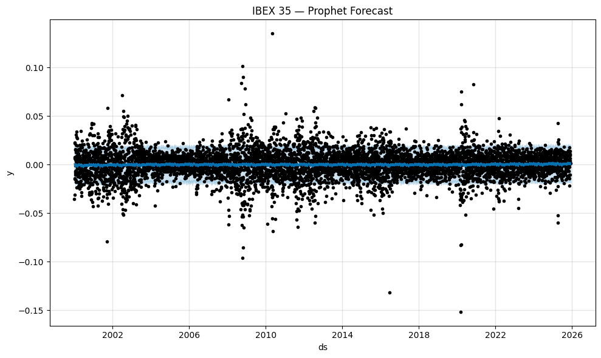

```
Saved: /home/apalo/projects/ibex-sp500-forecasting/figures/03.PROPHET/prophet_forecast_spx.png True
```

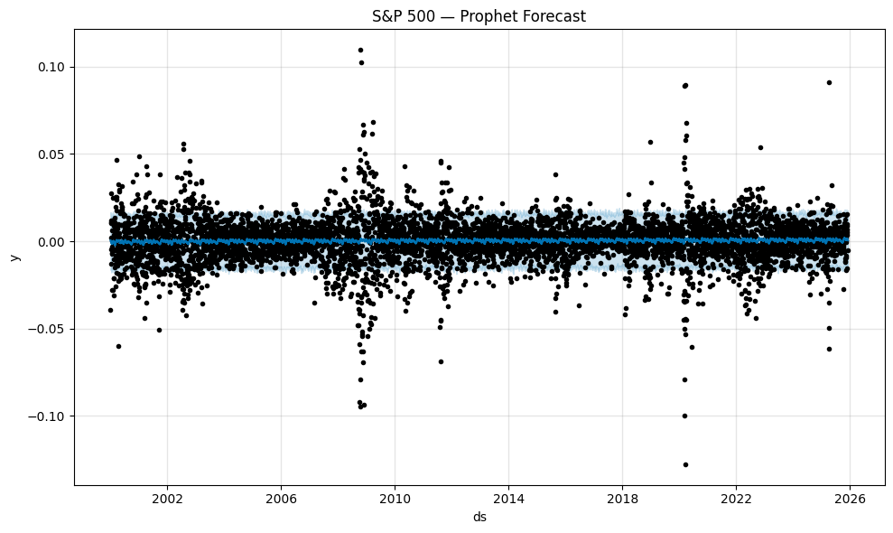

```
 Prophet figures saved and displayed.
```

```python
# 3. PROPHET MODELING
# Imports
import warnings
import pandas as pd
import matplotlib.pyplot as plt
from pathlib import Path
from prophet import Prophet
from IPython.display import display

from src.tests import jb_test
from src.visualization import plot_forecast

# Enable inline plotting
%matplotlib inline

# Setup directories and suppress warnings
FIG_DIR = ROOT / "figures" / "03.PROPHET"
MODEL_DIR = ROOT / "data" / "models"
FIG_DIR.mkdir(parents=True, exist_ok=True)
MODEL_DIR.mkdir(parents=True, exist_ok=True)

warnings.filterwarnings("ignore", category=UserWarning)
warnings.filterwarnings("ignore", message="FutureWarning")
warnings.filterwarnings("ignore", message="ConvergenceWarning")

print(f"Figures will be saved in: {FIG_DIR}")
print(f"Models  will be saved in: {MODEL_DIR}\n")

# 1. Prepare data for Prophet
print("Step 1 — Preparing data for Prophet format")

def prepare_prophet_df(series):
    """Convert pandas Series to Prophet-compatible DataFrame."""
    df = pd.DataFrame({
        "ds": series.index,
        "y": series.values
    })
    return df.dropna()

ibex_df = prepare_prophet_df(returns["IBEX_ret"])
spx_df  = prepare_prophet_df(returns["SPX_ret"])

display(ibex_df.head())
display(spx_df.head())

# 2. Fit Prophet models
print("\nStep 2 — Fitting Prophet models")

prophet_ibex = Prophet(daily_seasonality=False, weekly_seasonality=True, yearly_seasonality=True)
prophet_spx  = Prophet(daily_seasonality=False, weekly_seasonality=True, yearly_seasonality=True)

prophet_ibex.fit(ibex_df)
prophet_spx.fit(spx_df)

# 3. Forecast 1-day and 5-day ahead
print("\nStep 3 — Forecasting 1-day and 5-day ahead")

future_ibex = prophet_ibex.make_future_dataframe(periods=5, freq="B")
forecast_ibex_prophet = prophet_ibex.predict(future_ibex).tail(5)[["ds", "yhat"]].rename(columns={"yhat": "Forecast"})
forecast_ibex_prophet["Horizon"] = [1, 2, 3, 4, 5]

future_spx = prophet_spx.make_future_dataframe(periods=5, freq="B")
forecast_spx_prophet = prophet_spx.predict(future_spx).tail(5)[["ds", "yhat"]].rename(columns={"yhat": "Forecast"})
forecast_spx_prophet["Horizon"] = [1, 2, 3, 4, 5]

print("\nIBEX 35 Prophet forecasts:")
display(forecast_ibex_prophet)

print("\nS&P 500 Prophet forecasts:")
display(forecast_spx_prophet)

# 4. Residual diagnostics
print("\nStep 4 — Residual diagnostics")

def prophet_residuals(model, df):
    """Compute residuals for Prophet model."""
    forecast = model.predict(df)
    residuals = df["y"].values - forecast["yhat"].values
    return residuals

res_ibex = prophet_residuals(prophet_ibex, ibex_df)
res_spx  = prophet_residuals(prophet_spx, spx_df)

# Apply Jarque–Bera test (normality of residuals)
jb_ibex = jb_test(res_ibex)
jb_spx  = jb_test(res_spx)

diagnostics = pd.DataFrame([
    {"Index": "IBEX 35", "JB_stat": jb_ibex[0], "JB_pvalue": jb_ibex[1]},
    {"Index": "S&P 500", "JB_stat": jb_spx[0], "JB_pvalue": jb_spx[1]}
])

diag_path = MODEL_DIR / "prophet_diagnostics.csv"
diagnostics.to_csv(diag_path, index=False)

print(f"Residual diagnostics saved → {diag_path}")
display(diagnostics)

# 5. Plot forecasts and save figures

print("Saving Prophet figures into:", FIG_DIR)

# IBEX
fig_ibex = prophet_ibex.plot(prophet_ibex.predict(future_ibex))
plt.title("IBEX 35 — Prophet Forecast")
plt.tight_layout()

output_ibex = FIG_DIR / "prophet_forecast_ibex.png"
fig_ibex.savefig(output_ibex, dpi=300, bbox_inches="tight")
print("Saved:", output_ibex, output_ibex.exists())

plt.show()  # Show in notebook
plt.close(fig_ibex)

# SPX
fig_spx = prophet_spx.plot(prophet_spx.predict(future_spx))
plt.title("S&P 500 — Prophet Forecast")
plt.tight_layout()

output_spx = FIG_DIR / "prophet_forecast_spx.png"
fig_spx.savefig(output_spx, dpi=300, bbox_inches="tight")
print("Saved:", output_spx, output_spx.exists())

plt.show()  # Show in notebook
plt.close(fig_spx)

print("\n Prophet figures saved and displayed.")
```

# Technical Summary — Prophet Results

Residual diagnostics show high Jarque–Bera statistics (p < 0.05), indicating non-normal residuals.  
This behavior is expected as we show in the previous notebook (EDA), where we saw that heavy tails and volatility clustering dominate.

While ARIMA focuses on linear dependencies, Prophet offers a complementary non-linear framework capable of capturing structural breaks or regime changes, which is why we will later make a comparison between the results.

### Interpretation

The Prophet model provided smooth and stable forecasts for both indices, with predicted daily returns oscillating near zero, consistent with market efficiency expectations.

However, residual diagnostics (Jarque–Bera test) reveal strong deviations from normality, confirming that the model fails to capture the heavy tails and volatility clustering typical of financial returns.

This outcome is an inherent limitation of additive trend models when applied to high-frequency financial data.  
Prophet successfully captures non-linear trends and potential regime changes, but the conditional variance dynamics remain heteroscedastic.

These differences will be quantitatively compared in the next section and subsequently modeling the variance with **EGARCH** to handle volatility effects.

```
Step 1 — Computing performance metrics (MAE, RMSE)
```

|  | Model | Index | MAE | RMSE |
| --- | --- | --- | --- | --- |
| 0 | ARIMA | IBEX 35 | 0.005874 | 0.007624 |
| 1 | Prophet | IBEX 35 | 0.005795 | 0.007727 |
| 2 | ARIMA | S&P 500 | 0.007437 | 0.007559 |
| 3 | Prophet | S&P 500 | 0.007647 | 0.007699 |

```
Step 2 — Diebold–Mariano Test (ARIMA vs Prophet)
```

|  | Index | DM_stat | p_value |
| --- | --- | --- | --- |
| 0 | IBEX 35 | -0.739588 | 0.594598 |
| 1 | S&P 500 | -0.323742 | 0.800678 |

```
Step 3 — Visualization of forecast comparison
```

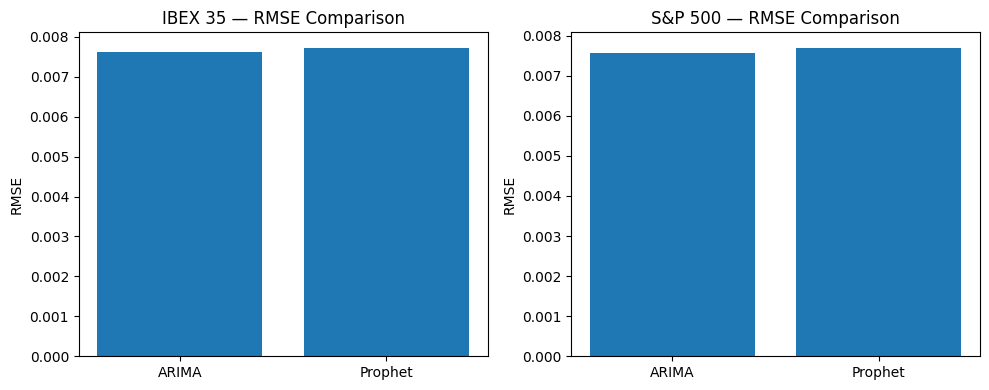

```
Saved in:
- /home/apalo/projects/ibex-sp500-forecasting/figures/03.ARIMA/rmse_comparison.png
- /home/apalo/projects/ibex-sp500-forecasting/figures/03.PROPHET/rmse_comparison.png

Comparison metrics saved → /home/apalo/projects/ibex-sp500-forecasting/data/models/arima_prophet_metrics.csv

 Model comparison complete — metrics, Diebold–Mariano test and visualizations displayed.
```

```python
import numpy as np

# Step 1 — Compute performance metrics (MAE & RMSE)

print("\nStep 1 — Computing performance metrics (MAE, RMSE)")

def compute_metrics(actual, predicted, model_name, label):
    mae = np.mean(np.abs(actual - predicted))
    rmse = np.sqrt(np.mean((actual - predicted)**2))
    return {"Model": model_name, "Index": label, "MAE": mae, "RMSE": rmse}

# Filter Prophet forecasts for horizons 1 and 5
forecast_ibex_prophet_filtered = forecast_ibex_prophet[forecast_ibex_prophet["Horizon"].isin([1, 5])]
forecast_spx_prophet_filtered  = forecast_spx_prophet[forecast_spx_prophet["Horizon"].isin([1, 5])]

# Actual returns for comparison (last + last-5)
actual_ibex = np.array([returns["IBEX_ret"].iloc[-1], returns["IBEX_ret"].iloc[-5]])
actual_spx  = np.array([returns["SPX_ret"].iloc[-1], returns["SPX_ret"].iloc[-5]])

# Compute metrics
metrics = []
metrics.append(compute_metrics(actual_ibex, forecast_ibex_arima["Forecast"].values, "ARIMA", "IBEX 35"))
metrics.append(compute_metrics(actual_ibex, forecast_ibex_prophet_filtered["Forecast"].values, "Prophet", "IBEX 35"))

metrics.append(compute_metrics(actual_spx, forecast_spx_arima["Forecast"].values, "ARIMA", "S&P 500"))
metrics.append(compute_metrics(actual_spx, forecast_spx_prophet_filtered["Forecast"].values, "Prophet", "S&P 500"))

metrics_df = pd.DataFrame(metrics)
display(metrics_df)

# Step 2 — Diebold–Mariano test

print("\nStep 2 — Diebold–Mariano Test (ARIMA vs Prophet)")

def diebold_mariano(e1, e2):
    d = (e1**2) - (e2**2)
    mean_d = np.mean(d)
    var_d = np.var(d, ddof=1)
    dm_stat = mean_d / np.sqrt(var_d / len(d))
    from scipy.stats import t
    p_value = 2 * (1 - t.cdf(abs(dm_stat), df=len(d) - 1))
    return dm_stat, p_value

errors_ibex_arima    = actual_ibex - forecast_ibex_arima["Forecast"].values
errors_ibex_prophet  = actual_ibex - forecast_ibex_prophet_filtered["Forecast"].values

errors_spx_arima     = actual_spx - forecast_spx_arima["Forecast"].values
errors_spx_prophet   = actual_spx - forecast_spx_prophet_filtered["Forecast"].values

dm_ibex = diebold_mariano(errors_ibex_arima, errors_ibex_prophet)
dm_spx  = diebold_mariano(errors_spx_arima, errors_spx_prophet)

dm_results = pd.DataFrame([
    {"Index": "IBEX 35", "DM_stat": dm_ibex[0], "p_value": dm_ibex[1]},
    {"Index": "S&P 500", "DM_stat": dm_spx[0], "p_value": dm_spx[1]}
])

display(dm_results)

# Step 3 — Visualization of forecast comparison

print("\nStep 3 — Visualization of forecast comparison")

fig, axes = plt.subplots(1, 2, figsize=(10, 4))

axes[0].bar(["ARIMA", "Prophet"], metrics_df.query("Index == 'IBEX 35'")["RMSE"])
axes[0].set_title("IBEX 35 — RMSE Comparison")
axes[0].set_ylabel("RMSE")

axes[1].bar(["ARIMA", "Prophet"], metrics_df.query("Index == 'S&P 500'")["RMSE"])
axes[1].set_title("S&P 500 — RMSE Comparison")
axes[1].set_ylabel("RMSE")

plt.tight_layout()
plt.show()

# Save figure to ARIMA and PROPHET folders
output_arima   = ROOT / "figures" / "03.ARIMA"   / "rmse_comparison.png"
output_prophet = ROOT / "figures" / "03.PROPHET" / "rmse_comparison.png"

fig.savefig(output_arima, dpi=300, bbox_inches="tight")
fig.savefig(output_prophet, dpi=300, bbox_inches="tight")

print("Saved in:")
print("-", output_arima)
print("-", output_prophet)

# Step 4 — Save metrics
results_path = MODEL_DIR / "arima_prophet_metrics.csv"
metrics_df.to_csv(results_path, index=False)
print(f"\nComparison metrics saved → {results_path}")

print("\n Model comparison complete — metrics, Diebold–Mariano test and visualizations displayed.")
```

### ARIMA vs Prophet Comparison

These results reinforce that predictability in returns is minimal, in line with the Efficient Market Hypothesis. The remaining structure lies in the volatility, not in the mean, motivating the next phase: conditional variance modelling (EGARCH).

## 5. Analytical Insights

This notebook explored the short-term return dynamics of the IBEX 35 and S&P 500, testing the presence of linear predictability through **ARIMA** and **Prophet** models.

Overall, the findings reinforce the fact that **daily log-returns are weakly stationary, exhibit low predictability, and show evidence of volatility clustering**. Such behaviour cannot be captured by ARIMA or Prophet, whose assumptions rely on constant variance. Therefore, the next step in the modelling process is to move from the mean equation to the variance equation, specifically by estimating **EGARCH models**, capable of representing:

- **Conditional heteroscedasticity** (time-varying volatility)
- **Leverage effects** (asymmetric volatility response to negative shocks)
- **Fat-tailed residual distributions** (Student-t)

## 6. Power BI Export Summary

```python
# FINAL EXPORTS FOR POWER BI — ARIMA + PROPHET + VALIDATION

import sys
from pathlib import Path
import pandas as pd

ROOT = Path.cwd().parent
sys.path.append(str(ROOT / "src"))

from export import export


# 1. Export ARIMA forecasts
try:
    export(forecast_ibex_arima, "arima_forecast_ibex")
    export(forecast_spx_arima, "arima_forecast_spx")
    print("ARIMA forecasts exported.")
except Exception as e:
    print("ARIMA forecast export skipped. Error:", e)


# 2. Export ARIMA residual diagnostics
try:
    export(validation_df, "arima_residual_diagnostics")
    print("ARIMA residual diagnostics exported.")
except Exception as e:
    print("ARIMA residual diagnostics export skipped. Error:", e)


# 3. Export Prophet forecasts
try:
    export(forecast_ibex_prophet, "prophet_forecast_ibex")
    export(forecast_spx_prophet, "prophet_forecast_spx")
    print("Prophet forecasts exported.")
except Exception as e:
    print("Prophet forecast export skipped. Error:", e)


# 4. Export Prophet residual diagnostics
try:
    export(diagnostics, "prophet_residual_diagnostics")
    print("Prophet diagnostics exported.")
except Exception as e:
    print("Prophet diagnostics export skipped. Error:", e)


# 5. Export ARIMA vs Prophet comparison (MAE, RMSE, DM test)
try:
    export(metrics_df, "arima_prophet_metrics")
    print("ARIMA vs Prophet comparison exported.")
except Exception as e:
    print("Comparison export skipped. Error:", e)


print("\nAll Power BI exports completed.")
```

```
[EXPORT] arima_forecast_ibex.csv saved to /mnt/c/Users/apalo/Desktop/forescasting_results/arima_forecast_ibex.csv
[EXPORT] arima_forecast_spx.csv saved to /mnt/c/Users/apalo/Desktop/forescasting_results/arima_forecast_spx.csv
ARIMA forecasts exported.
[EXPORT] arima_residual_diagnostics.csv saved to /mnt/c/Users/apalo/Desktop/forescasting_results/arima_residual_diagnostics.csv
ARIMA residual diagnostics exported.
[EXPORT] prophet_forecast_ibex.csv saved to /mnt/c/Users/apalo/Desktop/forescasting_results/prophet_forecast_ibex.csv
[EXPORT] prophet_forecast_spx.csv saved to /mnt/c/Users/apalo/Desktop/forescasting_results/prophet_forecast_spx.csv
Prophet forecasts exported.
[EXPORT] prophet_residual_diagnostics.csv saved to /mnt/c/Users/apalo/Desktop/forescasting_results/prophet_residual_diagnostics.csv
Prophet diagnostics exported.
[EXPORT] arima_prophet_metrics.csv saved to /mnt/c/Users/apalo/Desktop/forescasting_results/arima_prophet_metrics.csv
ARIMA vs Prophet comparison exported.

All Power BI exports completed.
```